# Bangladesh Adaptation Observation Survey Responses, Retrieval Date 15 April 2024.

Autogenerated data summary from dataMaid

2024-04-21 21:56:12.776542

# Data report overview

The dataset examined has the following dimensions:

| Feature | Result |
| --- | --- |
| Number of observations | 2260 |
| Number of variables | 60 |

### Checks performed

The following variable checks were performed, depending on the data type of each variable:

|  | character | factor | labelled | haven labelled | numeric | integer | logical | Date |
| --- | --- | --- | --- | --- | --- | --- | --- | --- |
| Identify miscoded missing values | × | × | × | × | × | × |  | × |
| Identify prefixed and suffixed whitespace | × | × | × | × |  |  |  |  |
| Identify levels with < 6 obs. | × | × | × | × |  |  |  |  |
| Identify case issues | × | × | × | × |  |  |  |  |
| Identify misclassified numeric or integer variables | × | × | × | × |  |  |  |  |
| Identify outliers |  |  |  |  | × | × |  | × |

Please note that all numerical values in the following have been rounded to 2 decimals.

# Summary table

|  | Variable class | # unique values | Missing observations | Any problems? |
| --- | --- | --- | --- | --- |
| start_date | character | 2256 | 0.00 % | × |
| end_date | character | 2250 | 0.00 % | × |
| status | character | 1 | 0.00 % | × |
| ip_address | character | 1874 | 0.00 % | × |
| progress | character | 3 | 0.00 % | × |
| duration_in_seconds | character | 762 | 0.00 % | × |
| finished | character | 2 | 0.00 % |  |
| recorded_date | character | 2251 | 0.00 % | × |
| response_id | character | 2260 | 0.00 % | × |
| recipient_last_name | character | 1 | 100.00 % | × |
| recipient_first_name | character | 1 | 100.00 % | × |
| recipient_email | character | 1 | 100.00 % | × |
| external_reference | character | 1 | 100.00 % | × |
| location_latitude | numeric | 123 | 0.66 % | × |
| location_longitude | numeric | 122 | 0.66 % | × |
| distribution_channel | character | 1 | 0.00 % | × |
| user_language | character | 2 | 0.00 % |  |
| meta_info_browser | character | 8 | 0.00 % | × |
| meta_info_version | character | 101 | 0.00 % | × |
| meta_info_operating_system | character | 23 | 0.00 % | × |
| meta_info_resolution | character | 188 | 0.00 % | × |
| consent_agreed | character | 1 | 0.00 % | × |
| consent_age | character | 1 | 0.00 % | × |
| consent_cellphone | character | 1 | 0.00 % | × |
| gps_permission | character | 1 | 0.00 % | × |
| household_move | character | 3 | 0.04 % |  |
| flood_year | character | 3 | 0.22 % |  |
| property_loss | character | 3 | 64.34 % |  |
| housing_damage | character | 3 | 64.56 % |  |
| stay_residence | character | 3 | 64.42 % |  |
| flood_close | character | 3 | 36.11 % |  |
| flood_prepared | character | 6 | 0.97 % |  |
| housing_safe | character | 6 | 1.64 % |  |
| climate_problem | character | 6 | 1.77 % |  |
| trust_government | character | 6 | 1.28 % |  |
| enough_eat | character | 3 | 0.22 % |  |
| move_rural_urban | character | 2 | 0.00 % |  |
| contact_authority | character | 3 | 0.13 % |  |
| demo_gender | character | 4 | 0.04 % |  |
| demo_age | character | 211 | 0.53 % | × |
| demo_income | character | 572 | 1.55 % | × |
| comp_phone1_try1 | character | 2172 | 0.00 % | × |
| comp_phone1_try2 | character | 2176 | 0.00 % | × |
| comp_phone2_try1 | character | 126 | 94.42 % | × |
| comp_phone2_try2 | character | 123 | 94.60 % | × |
| comp_phone3_try1 | character | 15 | 99.34 % | × |
| comp_phone3_try2 | character | 14 | 99.38 % | × |
| geo_lat | character | 923 | 58.32 % | × |
| geo_lng | character | 923 | 58.32 % | × |
| q_url | character | 2137 | 0.00 % | × |
| q_language | character | 2 | 0.00 % |  |
| gender | character | 3 | 3.67 % |  |
| region | character | 11 | 3.67 % |  |
| age | character | 4 | 3.67 % |  |
| geo_capability | character | 1 | 100.00 % | × |
| geo_status | character | 3 | 0.00 % |  |
| geo_error | character | 2 | 52.96 % | × |
| country | character | 1 | 100.00 % | × |
| no_surverys_submitted | integer | 9 | 0.00 % |  |
| income_brackets | character | 5 | 1.55 % |  |

# Variable list

## start_date

| Feature | Result |
| --- | --- |
| Variable type | character |
| Number of missing obs. | 0 (0 %) |
| Number of unique values | 2256 |
| Mode | “2024-03-25 21:10:23” |

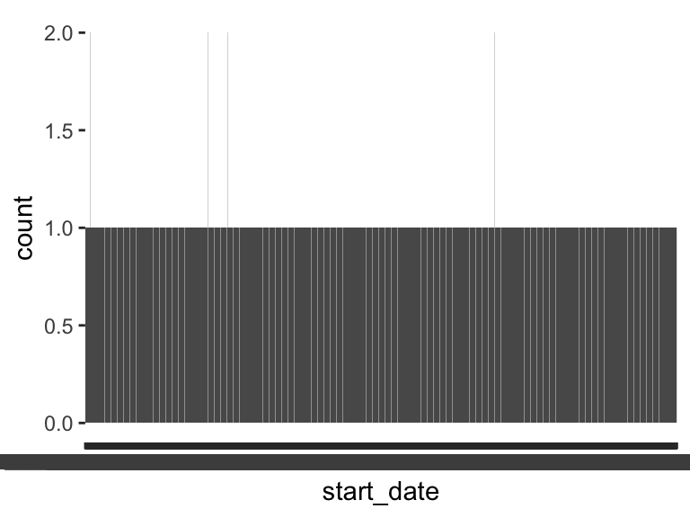

- Note that the following levels have at most five observations: "2024-03-25 20:23:58", "2024-03-25 20:26:10", "2024-03-25 20:30:07", "2024-03-25 20:33:38", "2024-03-25 20:40:42", …, "2024-04-05 12:12:01", "2024-04-05 12:35:39", "2024-04-05 16:35:39", "2024-04-05 18:06:17", "2024-04-09 10:26:44" (2246 values omitted).

## end_date

| Feature | Result |
| --- | --- |
| Variable type | character |
| Number of missing obs. | 0 (0 %) |
| Number of unique values | 2250 |
| Mode | “2024-03-25 21:56:26” |

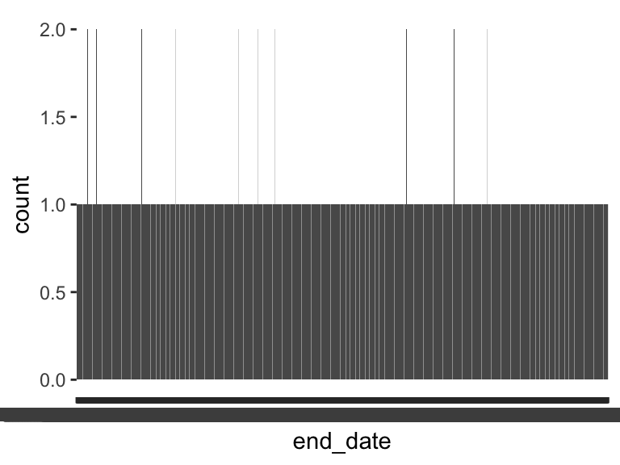

- Note that the following levels have at most five observations: "2024-03-25 20:30:54", "2024-03-25 20:36:21", "2024-03-25 20:36:34", "2024-03-25 20:42:34", "2024-03-25 20:44:17", …, "2024-04-05 12:35:22", "2024-04-05 12:38:01", "2024-04-05 16:37:57", "2024-04-05 18:08:17", "2024-04-09 10:32:38" (2240 values omitted).

## status

- The variable only takes one (non-missing) value: "IP Address". The variable contains 0 % missing observations.

## ip_address

| Feature | Result |
| --- | --- |
| Variable type | character |
| Number of missing obs. | 0 (0 %) |
| Number of unique values | 1874 |
| Mode | “103.146.42.192” |

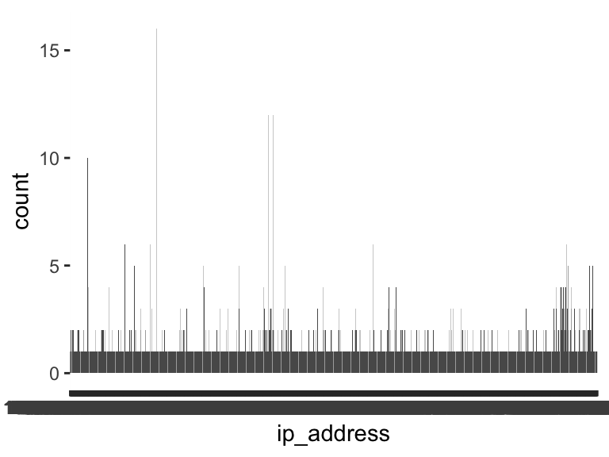

- Note that the following levels have at most five observations: "101.2.163.146", "101.2.164.46", "101.2.164.57", "101.2.167.130", "101.2.167.17", …, "59.153.103.110", "59.153.103.132", "59.153.103.247", "59.153.16.236", "59.153.17.202" (1856 values omitted).

## progress

| Feature | Result |
| --- | --- |
| Variable type | character |
| Number of missing obs. | 0 (0 %) |
| Number of unique values | 3 |
| Mode | “100” |

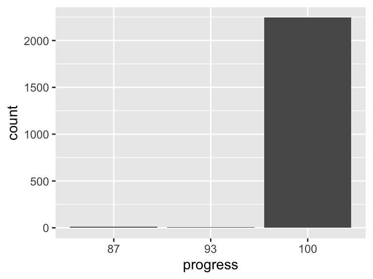

- Note that the following levels have at most five observations: "93".

## duration_in_seconds

| Feature | Result |
| --- | --- |
| Variable type | character |
| Number of missing obs. | 0 (0 %) |
| Number of unique values | 762 |
| Mode | “224” |

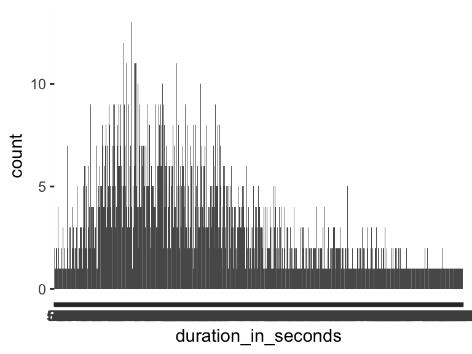

- Note that the following levels have at most five observations: "100", "1006", "1009", "101", "1010", …, "99", "991", "993", "997", "998" (641 values omitted).
- Note: The variable consists exclusively of numbers and takes a lot of different values. Is it perhaps a misclassified numeric variable?

## finished

| Feature | Result |
| --- | --- |
| Variable type | character |
| Number of missing obs. | 0 (0 %) |
| Number of unique values | 2 |
| Mode | “True” |

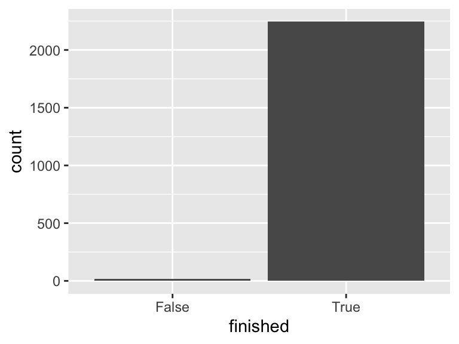

## recorded_date

| Feature | Result |
| --- | --- |
| Variable type | character |
| Number of missing obs. | 0 (0 %) |
| Number of unique values | 2251 |
| Mode | “2024-03-25 21:56:27” |

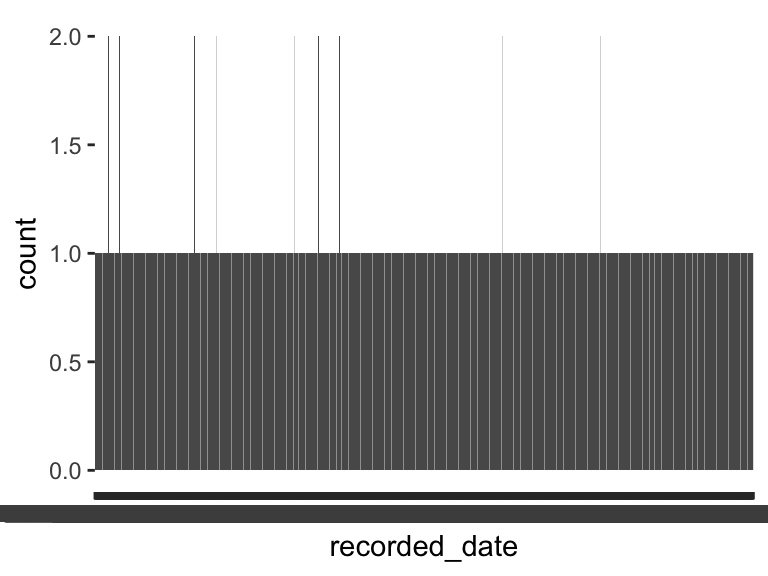

- Note that the following levels have at most five observations: "2024-03-25 20:30:55", "2024-03-25 20:36:22", "2024-03-25 20:36:35", "2024-03-25 20:42:34", "2024-03-25 20:44:18", …, "2024-04-06 07:03:35", "2024-04-06 12:36:06", "2024-04-07 02:26:47", "2024-04-07 18:01:43", "2024-04-09 10:32:39" (2241 values omitted).

## response_id

- The variable is a key (distinct values for each observation).

## recipient_last_name

- The variable only takes one value: "NA".

## recipient_first_name

- The variable only takes one value: "NA".

## recipient_email

- The variable only takes one value: "NA".

## external_reference

- The variable only takes one value: "NA".

## location_latitude

| Feature | Result |
| --- | --- |
| Variable type | numeric |
| Number of missing obs. | 15 (0.66 %) |
| Number of unique values | 122 |
| Median | 23.73 |
| 1st and 3rd quartiles | 23.7; 23.87 |
| Min. and max. | 1.31; 53.45 |

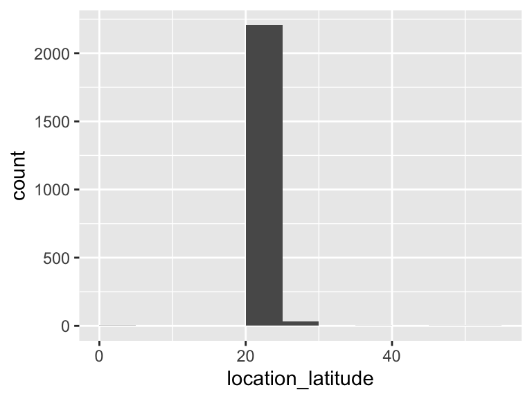

- Note that the following possible outlier values were detected: "1.31", "3.14", "21.42", "21.48", "22.22", …, "25.73", "26.12", "37.75", "48.83", "53.45" (37 values omitted).

## location_longitude

| Feature | Result |
| --- | --- |
| Variable type | numeric |
| Number of missing obs. | 15 (0.66 %) |
| Number of unique values | 121 |
| Median | 90.41 |
| 1st and 3rd quartiles | 90.37; 90.43 |
| Min. and max. | -97.82; 103.68 |

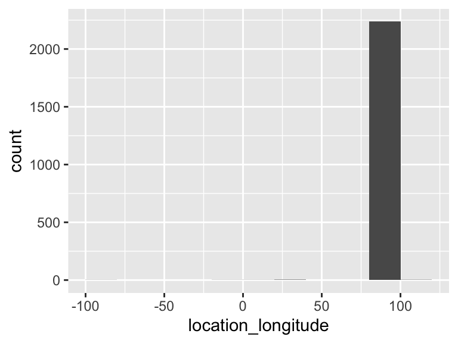

- Note that the following possible outlier values were detected: "-97.82", "-2.32", "2.41", "39.19", "39.82", …, "91.87", "92.17", "92.23", "101.69", "103.68" (84 values omitted).

## distribution_channel

- The variable only takes one (non-missing) value: "anonymous". The variable contains 0 % missing observations.

## user_language

| Feature | Result |
| --- | --- |
| Variable type | character |
| Number of missing obs. | 0 (0 %) |
| Number of unique values | 2 |
| Mode | “BN” |

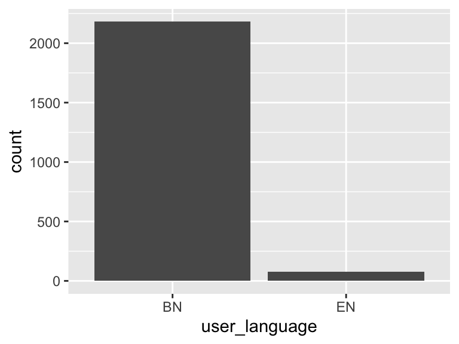

## meta_info_browser

| Feature | Result |
| --- | --- |
| Variable type | character |
| Number of missing obs. | 0 (0 %) |
| Number of unique values | 8 |
| Mode | “Chrome” |

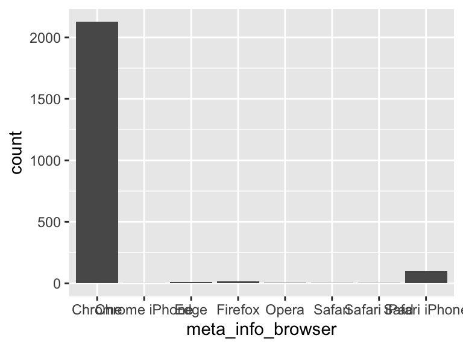

- Note that the following levels have at most five observations: "Chrome iPhone", "Opera", "Safari", "Safari iPad".

## meta_info_version

| Feature | Result |
| --- | --- |
| Variable type | character |
| Number of missing obs. | 0 (0 %) |
| Number of unique values | 101 |
| Mode | “122.0.6261.136” |

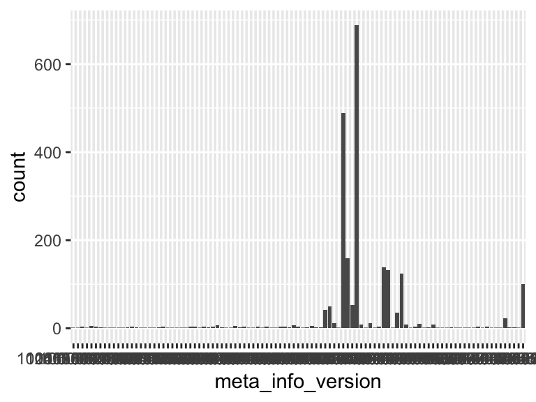

- Note that the following levels have at most five observations: "102.0.5005.125", "104.0.5112.97", "105.0.5195.136", "105.0.5195.79", "106.0.0.0", …, "94.0.4606.85", "95.0.0.0", "96.0.4664.104", "97.0.4692.98", "98.0.4758.101" (70 values omitted).

## meta_info_operating_system

| Feature | Result |
| --- | --- |
| Variable type | character |
| Number of missing obs. | 0 (0 %) |
| Number of unique values | 23 |
| Mode | “Android 13” |

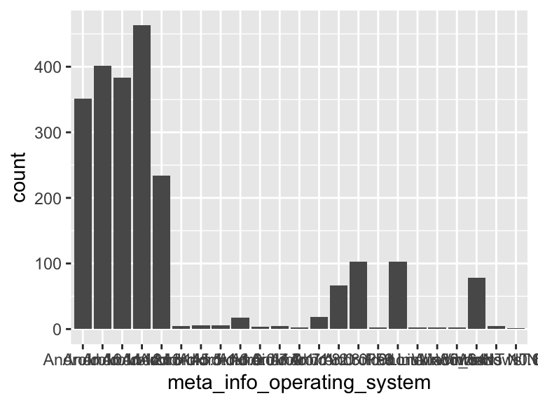

- Note that the following levels have at most five observations: "Android 5.1", "Android 7.0", "Android 7.1.1", "Android 7.1.2", "iPad", "Linux", "Linux x86_64", "Macintosh", "Windows NT 6.1", "Windows NT 6.3".

## meta_info_resolution

| Feature | Result |
| --- | --- |
| Variable type | character |
| Number of missing obs. | 0 (0 %) |
| Number of unique values | 188 |
| Mode | “360x800” |

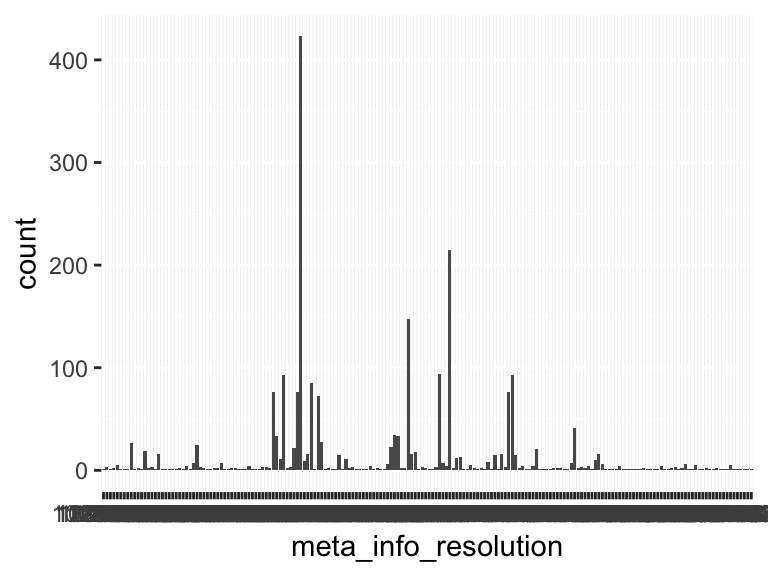

- Note that the following levels have at most five observations: "1024x640", "1024x768", "1098x618", "1280x1024", "1280x720", …, "768x1024", "820x1180", "851x393", "873x393", "942x424" (133 values omitted).

## consent_agreed

- The variable only takes one (non-missing) value: "I agree to participate". The variable contains 0 % missing observations.

## consent_age

- The variable only takes one (non-missing) value: "Yes". The variable contains 0 % missing observations.

## consent_cellphone

- The variable only takes one (non-missing) value: "Yes". The variable contains 0 % missing observations.

## gps_permission

- The variable only takes one (non-missing) value: "Yes". The variable contains 0 % missing observations.

## household_move

| Feature | Result |
| --- | --- |
| Variable type | character |
| Number of missing obs. | 1 (0.04 %) |
| Number of unique values | 2 |
| Mode | “No” |

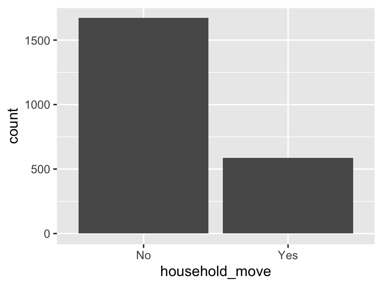

## flood_year

| Feature | Result |
| --- | --- |
| Variable type | character |
| Number of missing obs. | 5 (0.22 %) |
| Number of unique values | 2 |
| Mode | “No” |

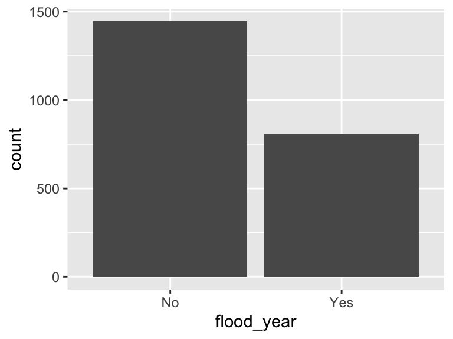

## property_loss

| Feature | Result |
| --- | --- |
| Variable type | character |
| Number of missing obs. | 1454 (64.34 %) |
| Number of unique values | 2 |
| Mode | “Yes” |

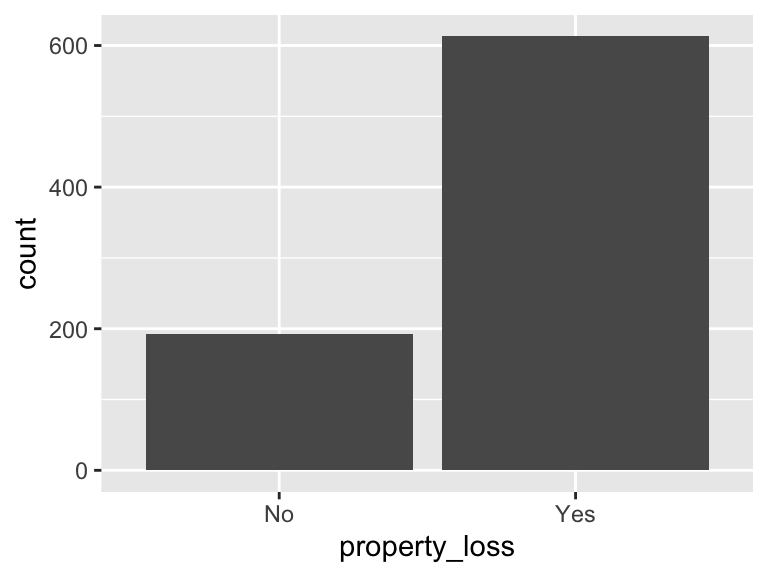

## housing_damage

| Feature | Result |
| --- | --- |
| Variable type | character |
| Number of missing obs. | 1459 (64.56 %) |
| Number of unique values | 2 |
| Mode | “Yes” |

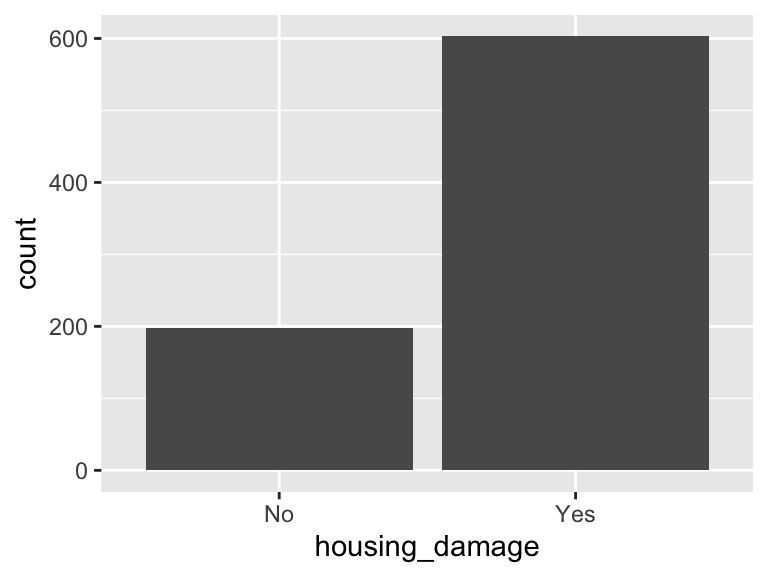

## stay_residence

| Feature | Result |
| --- | --- |
| Variable type | character |
| Number of missing obs. | 1456 (64.42 %) |
| Number of unique values | 2 |
| Mode | “Yes” |

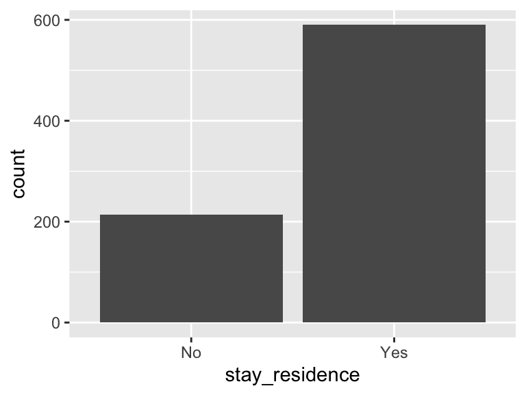

## flood_close

| Feature | Result |
| --- | --- |
| Variable type | character |
| Number of missing obs. | 816 (36.11 %) |
| Number of unique values | 2 |
| Mode | “No” |

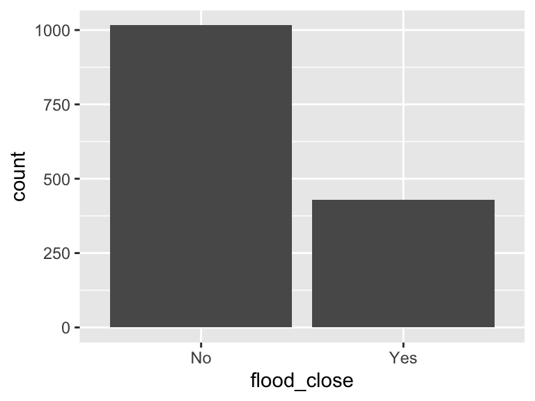

## flood_prepared

| Feature | Result |
| --- | --- |
| Variable type | character |
| Number of missing obs. | 22 (0.97 %) |
| Number of unique values | 5 |
| Mode | “Strongly agree” |

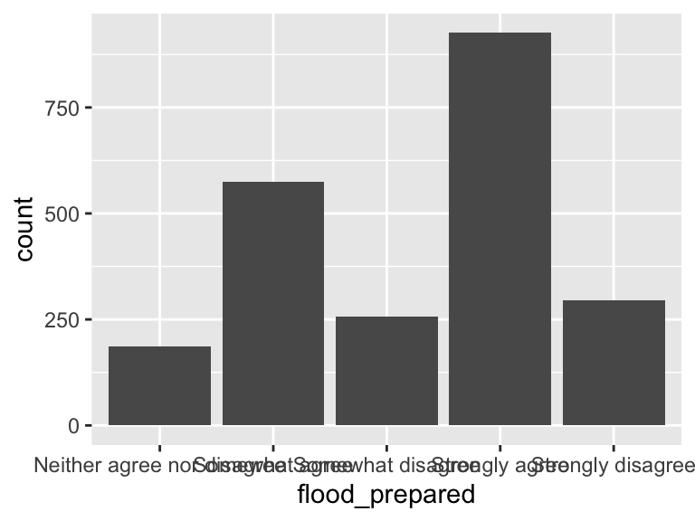

## housing_safe

| Feature | Result |
| --- | --- |
| Variable type | character |
| Number of missing obs. | 37 (1.64 %) |
| Number of unique values | 5 |
| Mode | “Strongly agree” |

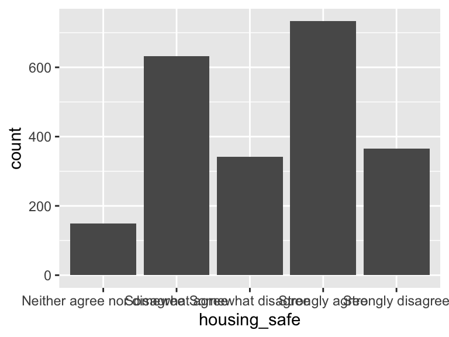

## climate_problem

| Feature | Result |
| --- | --- |
| Variable type | character |
| Number of missing obs. | 40 (1.77 %) |
| Number of unique values | 5 |
| Mode | “Strongly agree” |

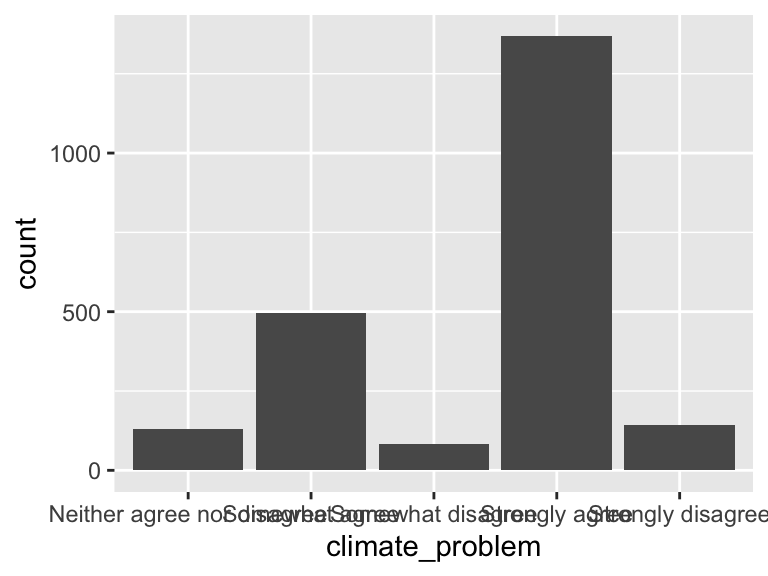

## trust_government

| Feature | Result |
| --- | --- |
| Variable type | character |
| Number of missing obs. | 29 (1.28 %) |
| Number of unique values | 5 |
| Mode | “Strongly agree” |

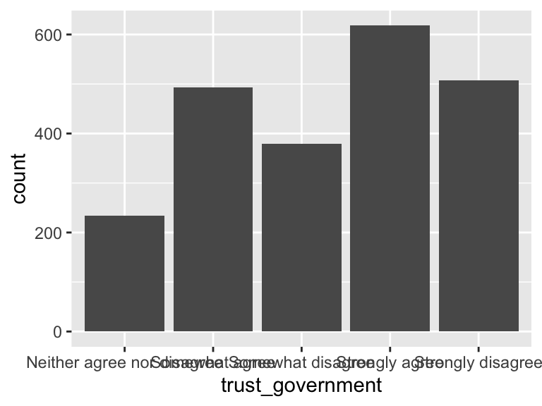

## enough_eat

| Feature | Result |
| --- | --- |
| Variable type | character |
| Number of missing obs. | 5 (0.22 %) |
| Number of unique values | 2 |
| Mode | “Yes” |

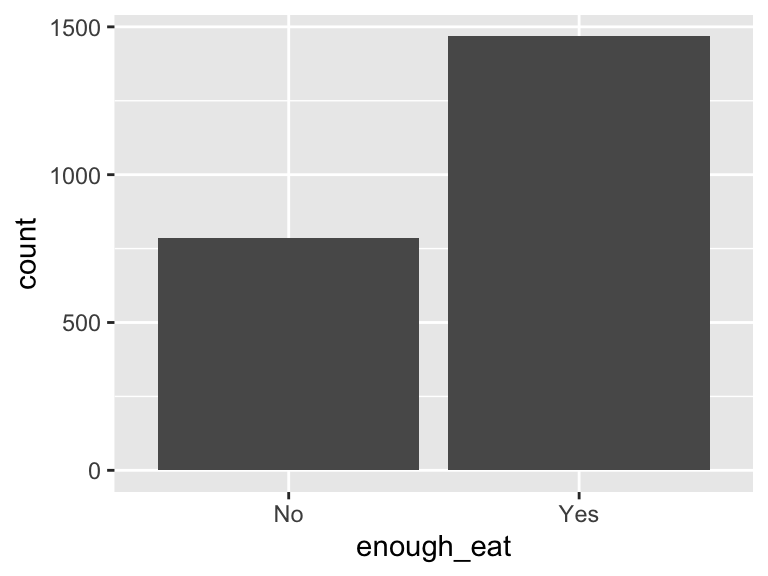

## move_rural_urban

| Feature | Result |
| --- | --- |
| Variable type | character |
| Number of missing obs. | 0 (0 %) |
| Number of unique values | 2 |
| Mode | “Yes” |

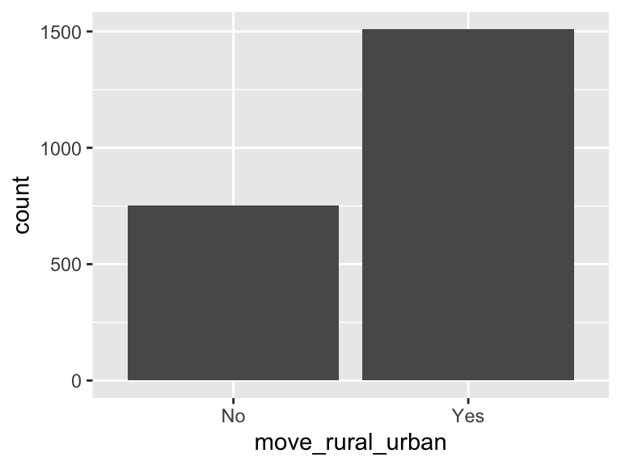

## contact_authority

| Feature | Result |
| --- | --- |
| Variable type | character |
| Number of missing obs. | 3 (0.13 %) |
| Number of unique values | 2 |
| Mode | “No” |

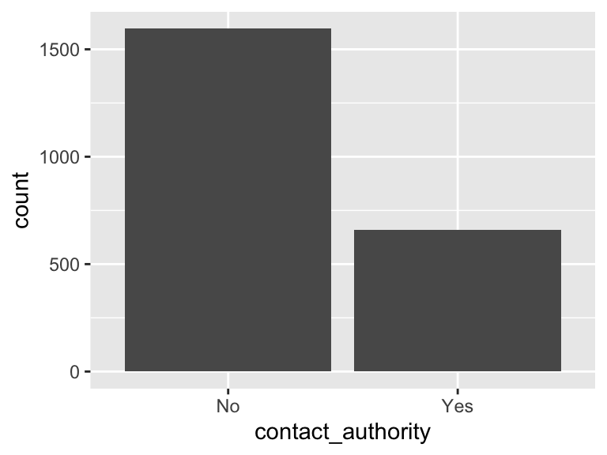

## demo_gender

| Feature | Result |
| --- | --- |
| Variable type | character |
| Number of missing obs. | 1 (0.04 %) |
| Number of unique values | 3 |
| Mode | “Male” |

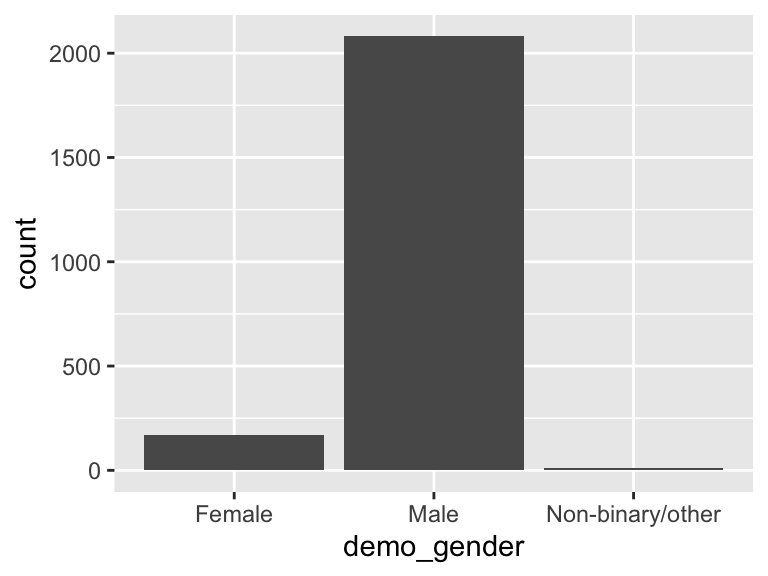

## demo_age

| Feature | Result |
| --- | --- |
| Variable type | character |
| Number of missing obs. | 12 (0.53 %) |
| Number of unique values | 210 |
| Mode | “30” |

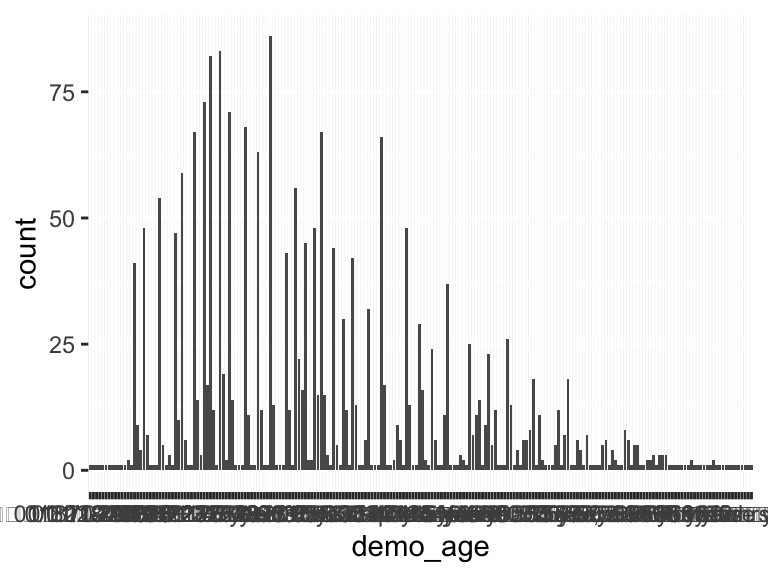

- Note that the following levels have at most five observations: "01.01.1970", "01/01/1978 ইং", "01822847824", "01870227288", "021", …, "Forty five years", "rwhrs", "ও৭", "চল্লিশ বছর", "তেইশ" (124 values omitted).

## demo_income

| Feature | Result |
| --- | --- |
| Variable type | character |
| Number of missing obs. | 35 (1.55 %) |
| Number of unique values | 571 |
| Mode | “10000” |

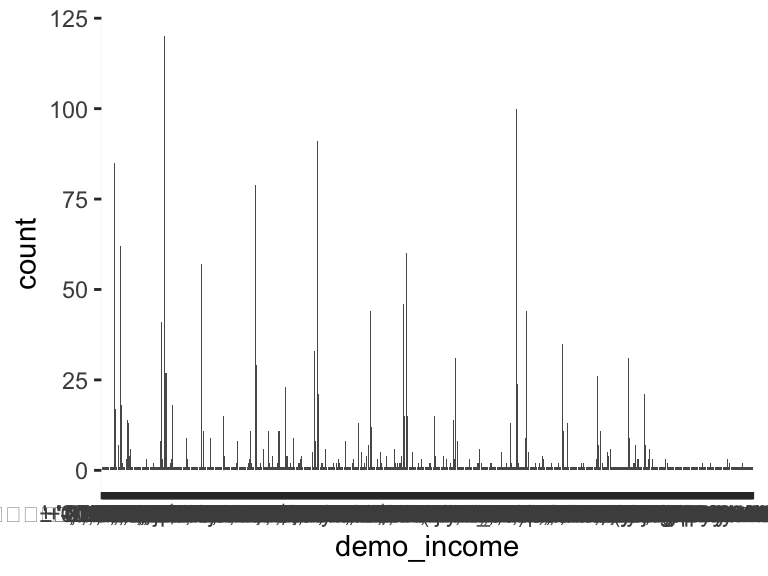

- The following suspected missing value codes enter as regular values: "-", "8".
- Note that the following levels have at most five observations: "-", "-10000", ",15000", "?", "’-১০০০০", …, "স্টুডেন্ট কমি", "স্টুডেন্ট বেকার", "হয় নাই", "হাঁ", "হিসাব নাই" (496 values omitted).
- Note that there might be case problems with the following levels: "6500tk", "6500TK", "no", "No".

## comp_phone1_try1

| Feature | Result |
| --- | --- |
| Variable type | character |
| Number of missing obs. | 0 (0 %) |
| Number of unique values | 2172 |
| Mode | “No” |

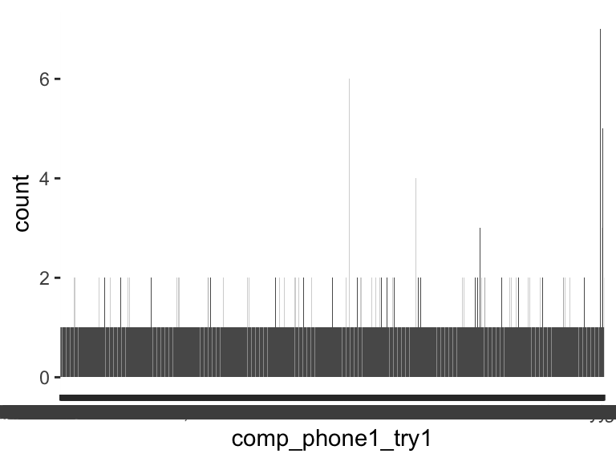

- The following suspected missing value codes enter as regular values: "Na".
- Note that the following levels have at most five observations: ",+8801834243469", "‘+৮৮ ০১৭১২০২২৫২২", "’+880 1643-153421 in", "‘+৮৮০১৬০৪৩১০৫৬৫", "’+৮৮০১৬০৫২২৮৩২২", …, "নিব না ৩০ টাকা", "প্রয়োজন হবে না।", "লাগবে না", "হে", "হ্যাঁ" (2160 values omitted).
- Note that there might be case problems with the following levels: "no", "No".

## comp_phone1_try2

| Feature | Result |
| --- | --- |
| Variable type | character |
| Number of missing obs. | 0 (0 %) |
| Number of unique values | 2176 |
| Mode | “No” |

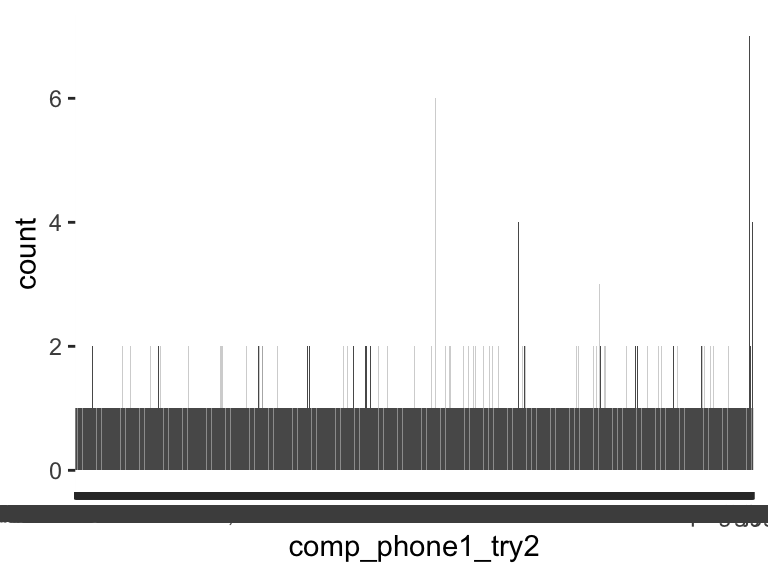

- The following suspected missing value codes enter as regular values: "Na".
- Note that the following levels have at most five observations: "-8801737670961", "‘+৮৮ ০১৭১২০২৩৫২২", "’+৮৮০১৬০৪৩১০৫৬৫", "‘+৮৮০১৬০৫২২৮৩২২", "’+৮৮০১৬৭৬৪৩৫৮৬৮", …, "দরকার নেই।", "ধুর", "না", "লাগবে না", "হে" (2164 values omitted).
- Note that there might be case problems with the following levels: "no", "No".

## comp_phone2_try1

| Feature | Result |
| --- | --- |
| Variable type | character |
| Number of missing obs. | 2134 (94.42 %) |
| Number of unique values | 125 |
| Mode | “01778346805” |

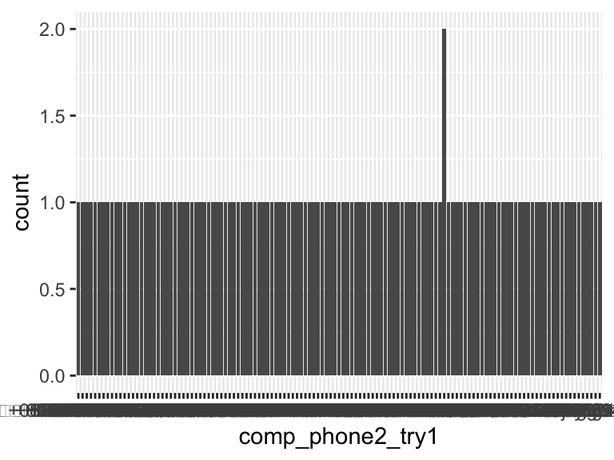

- Note that the following levels have at most five observations: "‘+৮৮০১৭৪১৩৮১৩৭৩", "’+৮৮০১৯৩৩৮৪৩৪৬৪", "+08801610264888", "+880 1515698708", "+8801303392056", …, "wtag", "চাই না", "বাংলাদেশ গ্রামীণফোন", "বুঝতে পারিনি", "হে" (115 values omitted).

## comp_phone2_try2

| Feature | Result |
| --- | --- |
| Variable type | character |
| Number of missing obs. | 2138 (94.6 %) |
| Number of unique values | 122 |
| Mode | “’+৮৮০১৭৪১৩৮১৩৭৩” |

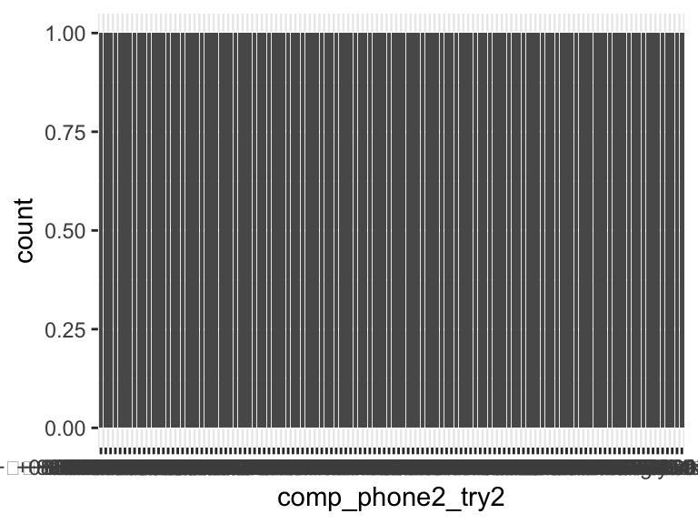

- Note that the following levels have at most five observations: "’+৮৮০১৭৪১৩৮১৩৭৩", "+08801610264888", "+880 1515698708", "+8801303392056", "+8801316400051", …, "I don’t want any compensation", "Sfbvf", "Sssss", "চাইনা", "বাড়িতে পেতে চায়" (112 values omitted).

## comp_phone3_try1

| Feature | Result |
| --- | --- |
| Variable type | character |
| Number of missing obs. | 2245 (99.34 %) |
| Number of unique values | 14 |
| Mode | “গ্রামীনে” |

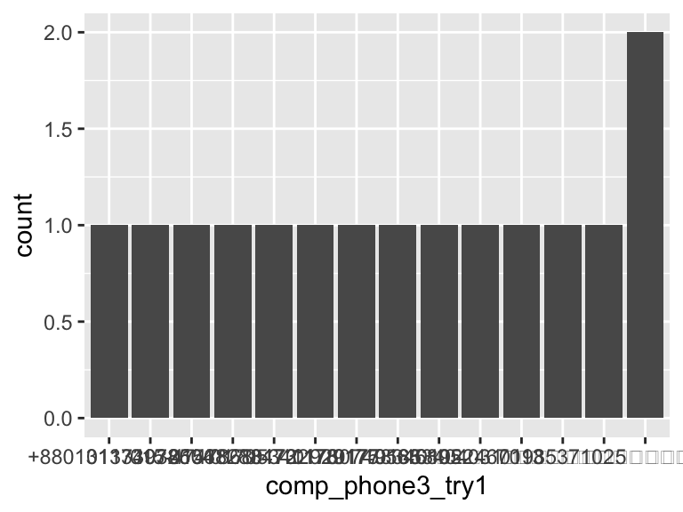

- Note that the following levels have at most five observations: "+8801311739785", "01334032604", "015-4747868", "01568288473", "01705341178", …, "01922467013", "০১৯৩৩৮৪৩৪৬৪", "01985371025", "৮৮০১৭১২১০৮৬০৬", "গ্রামীনে" (4 values omitted).

## comp_phone3_try2

| Feature | Result |
| --- | --- |
| Variable type | character |
| Number of missing obs. | 2246 (99.38 %) |
| Number of unique values | 13 |
| Mode | “01763705040” |

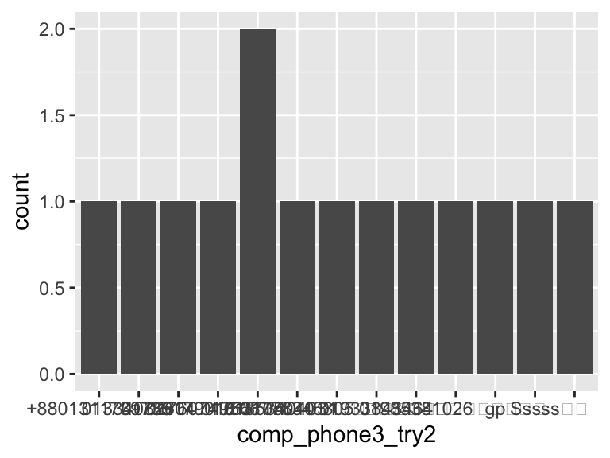

- Note that the following levels have at most five observations: "+8801311739785", "01334032604", "01739179018", "01760749568 I’m", "01763705040", …, "01985381026", "৮৮০১৭১২১০৮৬০৬", "gp", "Sssss", "হে" (3 values omitted).

## geo_lat

| Feature | Result |
| --- | --- |
| Variable type | character |
| Number of missing obs. | 1318 (58.32 %) |
| Number of unique values | 922 |
| Mode | “22.8229692” |

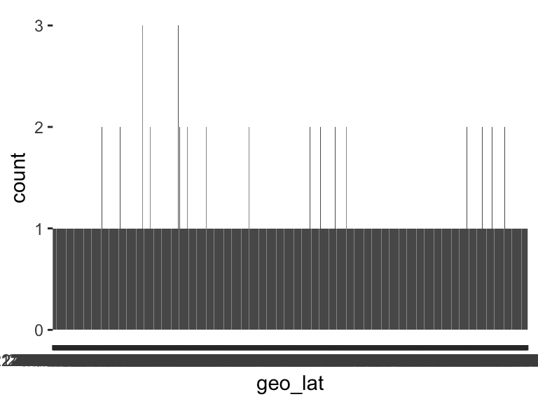

- Note that the following levels have at most five observations: "-7.8351606", "20.8720694", "20.9700061", "21.4215534", "21.4391383", …, "26.2326864", "26.3292006", "26.3367685", "3.129616050618498", "33.16335" (912 values omitted).
- Note: The variable consists exclusively of numbers and takes a lot of different values. Is it perhaps a misclassified numeric variable?

## geo_lng

| Feature | Result |
| --- | --- |
| Variable type | character |
| Number of missing obs. | 1318 (58.32 %) |
| Number of unique values | 922 |
| Mode | “89.5080243” |

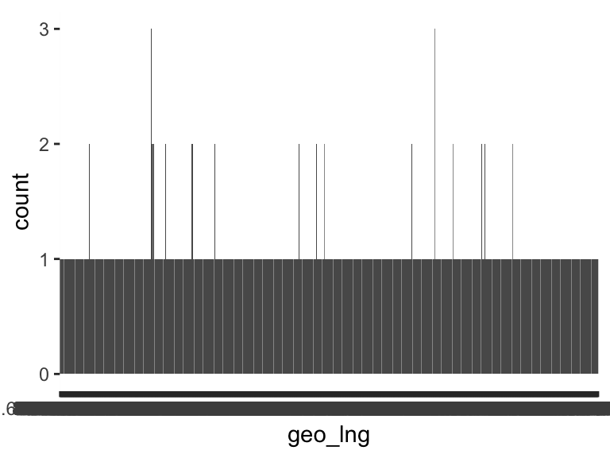

- Note that the following levels have at most five observations: "-96.72518", "101.67602495785316", "112.3778317", "39.608333553523906", "88.2008817", …, "92.1777242", "92.2481167", "92.2986433", "92.3696622", "92.3780385" (912 values omitted).
- Note: The variable consists exclusively of numbers and takes a lot of different values. Is it perhaps a misclassified numeric variable?

## q_url

| Feature | Result |
| --- | --- |
| Variable type | character |
| Number of missing obs. | 0 (0 %) |
| Number of unique values | 2137 |
| Mode | “https://ucsb.co1.qualtrics.com/jfe/form/SV_1N3JWXFRMjZdDls?Q_Language=BN®ion=Dhaka+%28first+half%29&gender=Male&age=18&fbclid=IwAR1SbBIa5z1Eqbv6L305z3PLNdTHfCHmLuS3eCK2BreN30Q1pc10pmwgPN8_aem_AX_qu9U… |

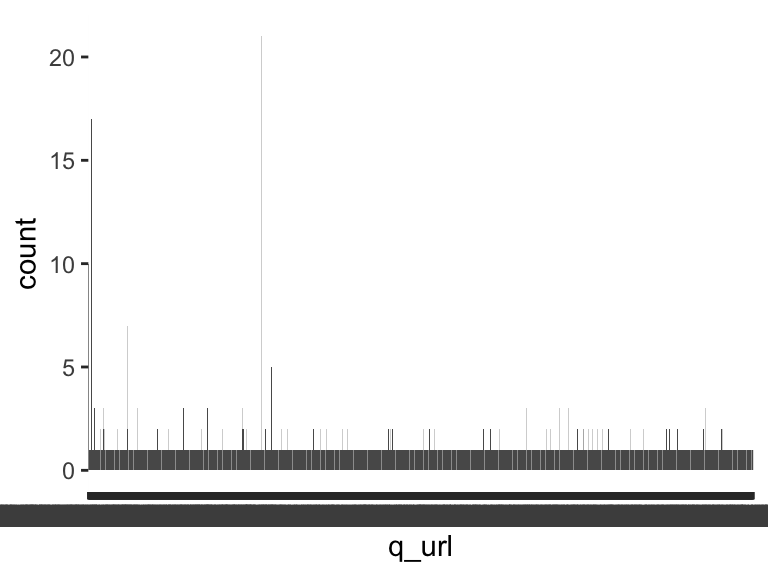

- Note that the following levels have at most five observations: "https://ucsb.co1.qualtrics.com/jfe/form/SV_1N3JWXFRMjZdDls?fbclid=IwAR0__8S2iaKxXCvV6q03JWLMVdHZZFLPeURKHbogwzVSyDrSRPhw5HZmS9Y\“, "https://ucsb.co1.qualtrics.com/jfe/form/SV_1N3JWXFRMjZdDls?fbclid=IwAR03_k8p7Q7Hfxg5_v6M6mayYdp-6tqR_iFVe4RDOpAbG3ybcldY3Ll-Rdc\”, "https://ucsb.co1.qualtrics.com/jfe/form/SV_1N3JWXFRMjZdDls?fbclid=IwAR0DjF3PqPA60Pa7GybUdDMT9nQW4-I0WOVgjmgGqh_dA-6_hLVhnM4mJZg\“, "https://ucsb.co1.qualtrics.com/jfe/form/SV_1N3JWXFRMjZdDls?fbclid=IwAR0eRIOcVjaRl_oxY0DKDMijVr_OVzw2CeQCtMF0hOaen-STXVM3MeM6pfo\”, "https://ucsb.co1.qualtrics.com/jfe/form/SV_1N3JWXFRMjZdDls?fbclid=IwAR0eSHjxLYAtN_lSJXwgTErTYT00GjYVLTLDorWWdcp2ccHijF7BHXBEx30\“, …, "https://ucsb.co1.qualtrics.com/jfe/form/SV_1N3JWXFRMjZdDls?Q_Language=BN®ion=Sylhet&gender=Male&age=50&fbclid=IwAR394AHdr2lBxAVZF5n3VaCuuiXRoUFOHp4IKpENpPEoL4Skn-EsAzodlyc_aem_AeGWoiFlYVcH4500S9M0E-YEaUByhsAc9nmmcEXz05G_EyMnUvu5pEcRiNOEo1A84lcyhq_u7U5KQouas7roZHgY\”, "https://ucsb.co1.qualtrics.com/jfe/form/SV_1N3JWXFRMjZdDls?Q_Language=BN®ion=Sylhet&gender=Male&age=50&fbclid=IwAR3fpxQLXL8UJVaB9BMhcbBwaItlaarTA4MqaVFvc05g9_5Wj1LgEO24DjU_aem_AUZNs8Re_bLtHIPiUvT1LS8iWsEeCCJiuSbJYmUgD-RiG0HKFkGszBWB1L4fxQq5Ph4KGT1jU_mlzWjX5-YMX_8e\“, "https://ucsb.co1.qualtrics.com/jfe/form/SV_1N3JWXFRMjZdDls?Q_Language=BN®ion=Sylhet&gender=Male&age=50&fbclid=IwAR3g8qVQC8-fkZjadiH98HDE111SI4FGplc0sF8TalvldfbZSMWgXDK62zo_aem_AX8ybNB4s00uwarA7wvXnye6E9Ooa6zaNKZ1uwDNyMf716ZThgoTKFBq8MefQ20fCa4mjNap_-Sy4xLN6sjTzaz6\”, "https://ucsb.co1.qualtrics.com/jfe/form/SV_1N3JWXFRMjZdDls?Q_Language=BN®ion=Sylhet&gender=Male&age=50&fbclid=IwAR3rLoGBpoe_xxPyKzoRdAU4EvCbn-UrX6Cd49aISE6e-lGJKy2vXPecpno_aem_AQL-clGp2aAYz8AEFXsed-Z1pyxY27k7Tc_I8pceCoXQCEPU5PfvKZ2-gMY47iAcm0jZGIwwvozDWLHziqGl3Zpc\“, "https://ucsb.co1.qualtrics.com/jfe/form/SV_1N3JWXFRMjZdDls?Q_Language=BN®ion=Sylhet&gender=Male&age=50&fbclid=IwAR3XZZEzcl0y8dEHpFIDJchu2s5yvOY3-2DdVEQ9OHE0jv7mG8AtdLm-edA_aem_AQLq9-A1QmCEYimyQSZZ03O_XoFgoNdtSzGfIdn2j-A3W5l1fZ4JMOnMcRciapDOytY6O3oKk-3_8YoHZhPGTNxM\” (2123 values omitted).

## q_language

| Feature | Result |
| --- | --- |
| Variable type | character |
| Number of missing obs. | 0 (0 %) |
| Number of unique values | 2 |
| Mode | “BN” |

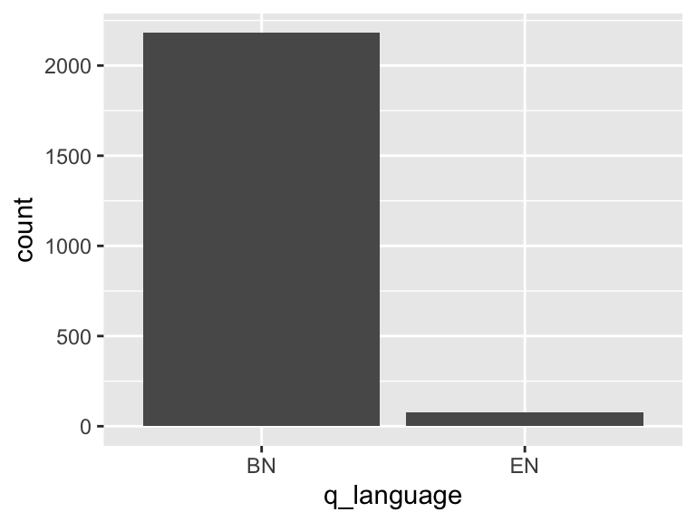

## gender

| Feature | Result |
| --- | --- |
| Variable type | character |
| Number of missing obs. | 83 (3.67 %) |
| Number of unique values | 2 |
| Mode | “Male” |

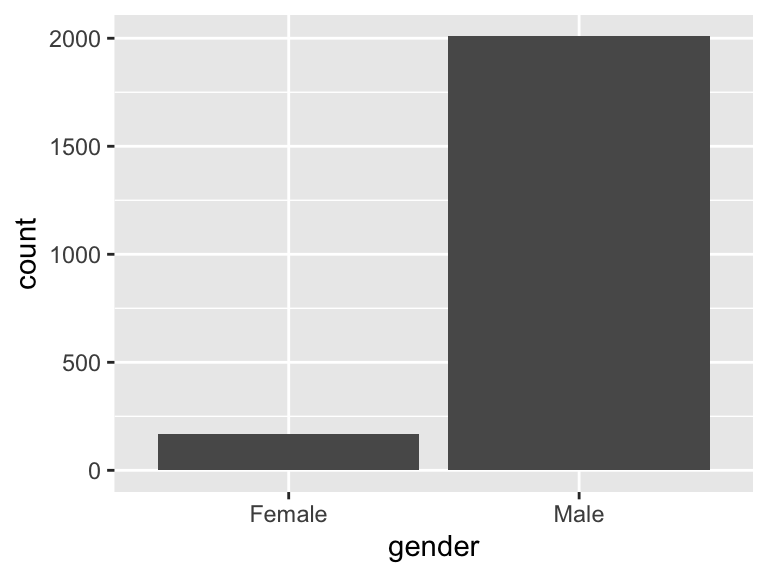

## region

| Feature | Result |
| --- | --- |
| Variable type | character |
| Number of missing obs. | 83 (3.67 %) |
| Number of unique values | 10 |
| Mode | “Dhaka (first half)” |

[figure not shown]

## age

| Feature | Result |
| --- | --- |
| Variable type | character |
| Number of missing obs. | 83 (3.67 %) |
| Number of unique values | 3 |
| Mode | “30” |

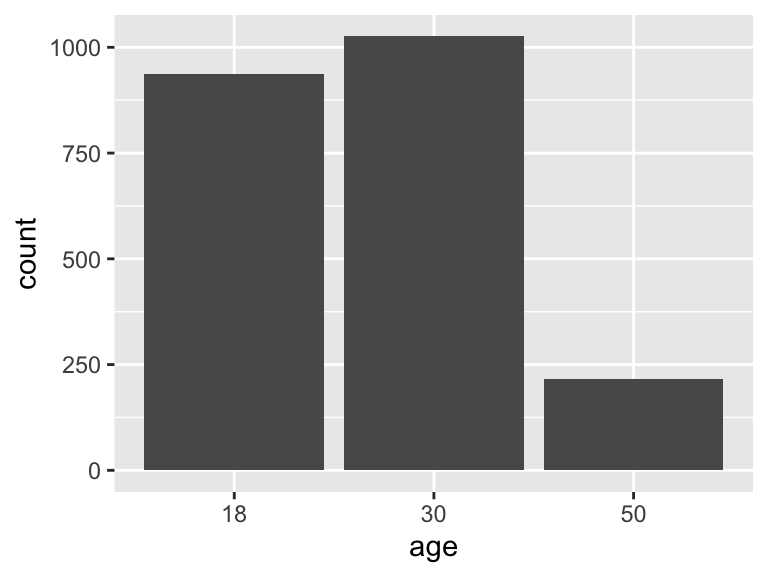

## geo_capability

- The variable only takes one value: "NA".

## geo_status

| Feature | Result |
| --- | --- |
| Variable type | character |
| Number of missing obs. | 0 (0 %) |
| Number of unique values | 3 |
| Mode | “-1” |

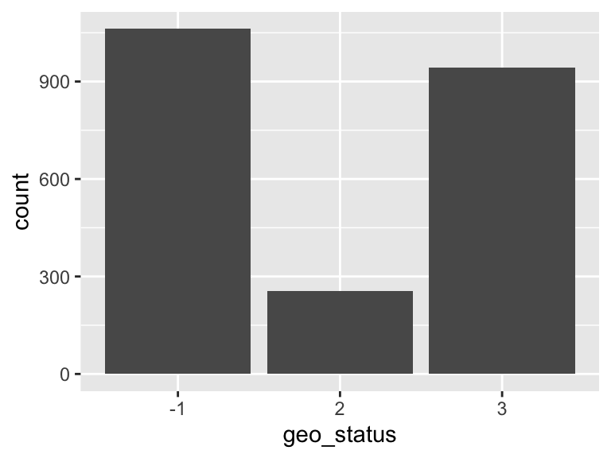

## geo_error

- The variable only takes one (non-missing) value: "error". The variable contains 52.96 % missing observations.

## country

- The variable only takes one value: "NA".

## no_surverys_submitted

| Feature | Result |
| --- | --- |
| Variable type | integer |
| Number of missing obs. | 0 (0 %) |
| Number of unique values | 9 |
| Median | 1 |
| 1st and 3rd quartiles | 1; 2 |
| Min. and max. | 1; 16 |

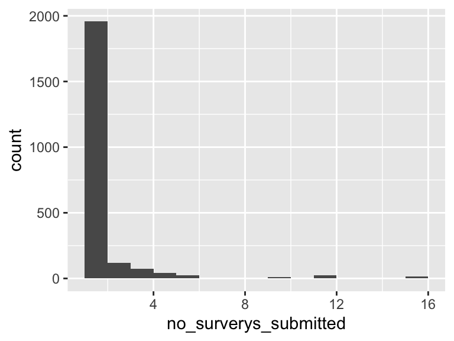

## income_brackets

| Feature | Result |
| --- | --- |
| Variable type | character |
| Number of missing obs. | 35 (1.55 %) |
| Number of unique values | 4 |
| Mode | “0% Tax Rate (Up to BDT 300,000)” |

[figure not shown]

Report generation information:

- Created by: Sofia Ingersoll (username: `sofiaingersoll`).
- Report creation time: Sun Apr 21 2024 21:56:14
- Report was run from directory: `/Users/sofiaingersoll/2035/Adaptation_Observatory/response_analysis/dataMaid`
- dataMaid v1.4.1 [Pkg: 2021-10-08 from CRAN (R 4.3.0)]
- R version 4.3.2 (2023-10-31).
- Platform: aarch64-apple-darwin20 (64-bit)(America/Los_Angeles).
- Function call: `makeDataReport(data = bgd, output = "html", replace = TRUE, reportTitle = "Bangladesh Adaptation Observation Survey Responses, Retrieval Date 15 April 2024.")`